# **PCFL 2023: Week 9 wrap-up**

The bye weeks are ongoing y’all. Also, this week’s Sunday Europe game is Colts-Patriots, kicking off at 9:30 ET. Check your lineups!!

## Last week’s games

[output not shown]

## Best performances

### Best players overall

Here’s last week’s **10 best performing starters.**

| Player | Position | NFL Team | Points | PCFL Team |
| --- | --- | --- | --- | --- |
| Dak Prescott | QB | DAL | 28.36 | Pigskin on the Gridiron |
| Chargers D/ST | DST | LAC | 26.00 | Southern Sharks |
| Jalen Hurts | QB | PHI | 25.88 | The Seniors |
| Josh Allen | QB | BUF | 24.72 | The G.O.A.T. |
| Browns D/ST | DST | CLE | 23.00 | The G.O.A.T. |
| CeeDee Lamb | WR | DAL | 22.60 | Middle Earth Hangry Hobbits |
| Joe Burrow | QB | CIN | 22.32 | Athens Team Sasquatch |
| Josh Jacobs | RB | OAK | 21.80 | Captain Clairvoyant |
| Rhamondre Stevenson | RB/WR/TE | NEP | 20.90 | Southern Sharks |
| Cole Kmet | TE | CHI | 20.50 | KC Gophers |

Check out the Chargers defense this week!

### Best players per team

Here’s last week’s top players **on each team.**

| Player | Position | NFL Team | Points | PCFL Team |
| --- | --- | --- | --- | --- |
| Tank Dell | BE | HOU | 29.15 | Athens Team Sasquatch |
| Dalton Schultz | BE | HOU | 22.00 | Captain Clairvoyant |
| C.J. Stroud | BE | HOU | 41.80 | Georgia Peanuts |
| Rachaad White | BE | TBB | 25.90 | Jumpin’ Jaheims |
| Cole Kmet | TE | CHI | 20.50 | KC Gophers |
| CeeDee Lamb | WR | DAL | 22.60 | Middle Earth Hangry Hobbits |
| Dak Prescott | QB | DAL | 28.36 | Pigskin on the Gridiron |
| Chargers D/ST | DST | LAC | 26.00 | Southern Sharks |
| Josh Allen | QB | BUF | 24.72 | The G.O.A.T. |
| Jalen Hurts | QB | PHI | 25.88 | The Seniors |

I benched CJ Stroud, thinking his rookie mojo had run out. Then he scores 42. Sigh. Relately, Tank Dell scored nearly 30 on Robbie’s bench.

### Best bench

Who won the **best scoring bench** award last week?

| Team | Bench points |
| --- | --- |
| Jumpin’ Jaheims | 80.52 |
| Georgia Peanuts | 75.90 |
| Pigskin on the Gridiron | 66.92 |
| Athens Team Sasquatch | 65.55 |
| Middle Earth Hangry Hobbits | 58.50 |
| Captain Clairvoyant | 32.50 |
| The G.O.A.T. | 28.20 |
| The Seniors | 19.20 |
| Southern Sharks | 15.20 |
| KC Gophers | 15.10 |

Here’s the season’s bench standings:

| Team | Bench points |
| --- | --- |
| Georgia Peanuts | 606.58 |
| Jumpin’ Jaheims | 567.88 |
| Athens Team Sasquatch | 549.26 |
| Pigskin on the Gridiron | 504.05 |
| Middle Earth Hangry Hobbits | 495.91 |
| Southern Sharks | 478.50 |
| Captain Clairvoyant | 447.44 |
| The Seniors | 446.39 |
| The G.O.A.T. | 425.62 |
| KC Gophers | 395.10 |

I’ve got a comfortable lead at this point. Evan and Robbie are the only ones within 100 points.

### Best optimized lineups

I compared the actual starting lineups for each team to the hypothetical *best* starting lineup the owner could have started. The table below shows the actual points the team scored, the top score they could have had, and an “optimization” percentage that compares to the two.

| PCFL Team | Actual points | Best lineup | Optimization rate |
| --- | --- | --- | --- |
| The Seniors | 98.68 | 99.28 | 99% |
| Southern Sharks | 89.40 | 98.40 | 91% |
| Middle Earth Hangry Hobbits | 103.08 | 113.92 | 90% |
| KC Gophers | 91.50 | 102.90 | 89% |
| The G.O.A.T. | 121.72 | 137.12 | 89% |
| Captain Clairvoyant | 89.90 | 113.40 | 79% |
| Pigskin on the Gridiron | 85.96 | 115.06 | 75% |
| Jumpin’ Jaheims | 101.64 | 147.32 | 69% |
| Georgia Peanuts | 89.14 | 135.30 | 66% |
| Athens Team Sasquatch | 88.62 | 150.67 | 59% |

Robbie could have had a 151 point week!

For the *whole season*, here’s a graph of actual points scored vs. optimized points given the roster.

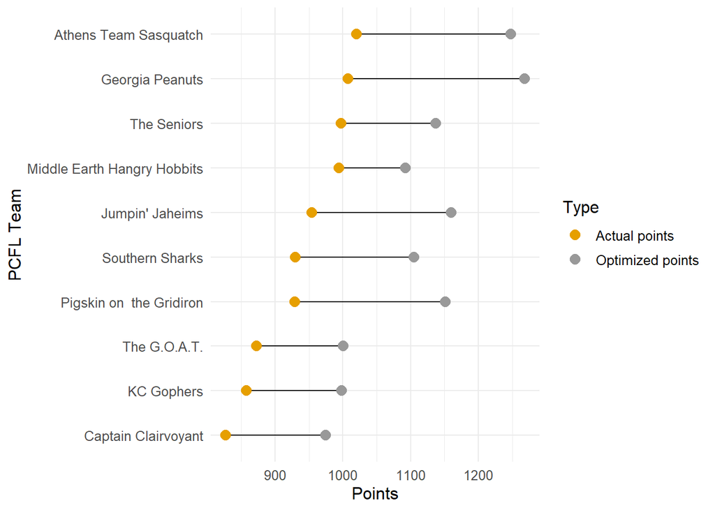

### Point distribution by position

Here’s a breakdown of point contribution by position by team so far this season.

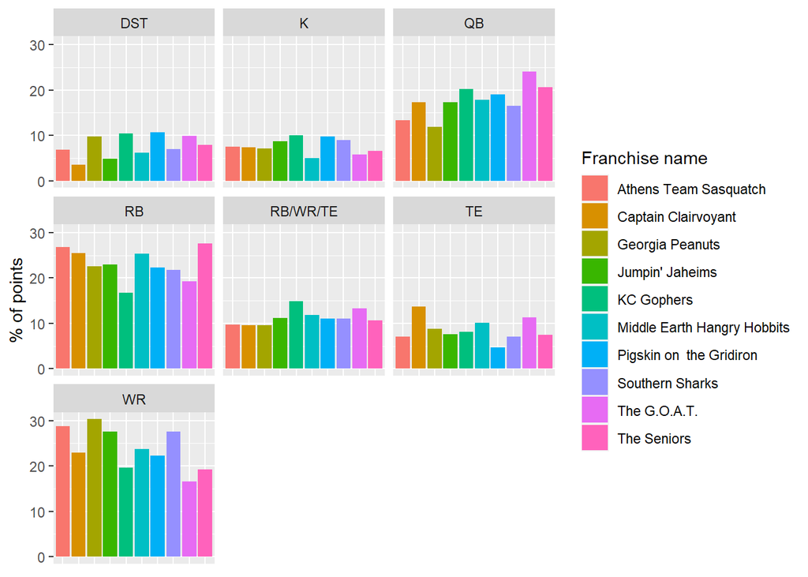

Fun facts:

- The GOAT is tops in percentage of points from the QB position (24%) but last in WR points (17%).
- Brian has now gotten **29 TOTAL POINTS** from his DST position ALL SEASON. The Chargers defense scored 26 LAST WEEK.
- The Gophers are the only team with 10% or more of points coming from their kicker.

### Best pick-ups

There were 11 players added last week. Which was the **best pick-ups**?

| PCFL Team | Player | NFL Team | Position | Points |
| --- | --- | --- | --- | --- |
| The G.O.A.T. | Cade Otton | TBB | TE | 20.0 |
| Southern Sharks | Baker Mayfield | TBB | QB | 19.0 |
| Middle Earth Hangry Hobbits | Jake Ferguson | DAL | TE | 18.6 |
| Jumpin’ Jaheims | Raiders D/ST | OAK | DST | 18.0 |
| Captain Clairvoyant | Sam Howell | WAS | QB | 17.7 |
| Georgia Peanuts | Dustin Hopkins | CLE | K | 9.0 |
| Southern Sharks | Rashee Rice | KCC | WR | 8.7 |
| The G.O.A.T. | Ka’imi Fairbairn | HOU | K | 6.0 |
| Southern Sharks | Trey McBride | ARI | TE | 3.7 |
| Captain Clairvoyant | Jonathan Mingo | CAR | WR | 1.0 |
| Pigskin on the Gridiron | Jaguars D/ST | JAC | DST | 0.0 |

### Best team performances

Here’s a list of the **top five scoring performances** so far this season.

| PCFL Team | Week | Score | Result |
| --- | --- | --- | --- |
| Athens Team Sasquatch | 8 | 180.02 | W |
| Middle Earth Hangry Hobbits | 2 | 167.18 | W |
| Jumpin’ Jaheims | 4 | 149.98 | W |
| Georgia Peanuts | 4 | 148.64 | W |
| The Seniors | 3 | 146.88 | W |

## Looking ahead

### League standings

| PCFL Team | Division | Points scored | Avg points | Avg last 3 | W | L | Team points |
| --- | --- | --- | --- | --- | --- | --- | --- |
| Athens Team Sasquatch | Grits | 1020.26 | 113.36 | 126.89 | 6 | 3 | 11 |
| Georgia Peanuts | Hot Dish | 1007.66 | 111.96 | 111.60 | 5 | 4 | 11 |
| Middle Earth Hangry Hobbits | Hot Dish | 994.04 | 110.45 | 122.48 | 5 | 4 | 11 |
| The Seniors | Hot Dish | 997.63 | 110.85 | 99.83 | 4 | 5 | 10 |
| Southern Sharks | Hot Dish | 930.30 | 103.37 | 89.38 | 4 | 5 | 10 |
| Pigskin on the Gridiron | Grits | 929.42 | 103.27 | 95.14 | 5 | 4 | 9 |
| The G.O.A.T. | Grits | 872.77 | 96.97 | 103.83 | 5 | 4 | 9 |
| Jumpin’ Jaheims | Grits | 954.48 | 106.05 | 106.61 | 4 | 5 | 8 |
| KC Gophers | Hot Dish | 850.08 | 94.45 | 80.52 | 3 | 6 | 6 |
| Captain Clairvoyant | Grits | 826.88 | 91.88 | 98.45 | 4 | 5 | 5 |

And even with the loss last week, Robbie still sits as the number one seed going into week 10. Brian’s got the lead for the toilet trophy.

### If the season ended today…

It’s Robbie, me, Scott, and Erin/Trav right now. Sarah is tied with Erin on team points, but the Sharks have scored about 70 fewer points.

### This week’s matchups

| Team 1 | Team 2 |
| --- | --- |
| Athens Team Sasquatch (Avg. last 3: 126.89) | Georgia Peanuts (Avg. last 3: 111.6) |
| Captain Clairvoyant (Avg. last 3: 98.45) | Pigskin on the Gridiron (Avg. last 3: 95.14) |
| Jumpin’ Jaheims (Avg. last 3: 106.61) | The G.O.A.T. (Avg. last 3: 103.83) |
| KC Gophers (Avg. last 3: 80.52) | Southern Sharks (Avg. last 3: 89.38) |
| Middle Earth Hangry Hobbits (Avg. last 3: 122.48) | The Seniors (Avg. last 3: 99.83) |

It’s #1 and #2 this week as I take on Robbie.

Good luck, y’all!